# Importance du soutien à la recherche pour la création de start-up

27.09.2023

**Une étude le prouve : le FNS et Innosuisse favorisent la création de start-up en soutenant la recherche. De nombreuses idées commerciales naissent dans les hautes écoles et d’autres institutions de recherche. Toute la société en profite.**

Les start-up utilisent les connaissances fondamentales issues de la recherche et développent de nouvelles applications techniques. Elles sont donc un moteur important de l’innovation. Dans quelle mesure l’encouragement de la recherche contribue-t-il à la création de telles entreprises en Suisse ? En collaboration avec Innosuisse, le FNS a commandé une étude à ce sujet.

### 470 jeunes entreprises sous la loupe

Le FNS et Innosuisse ont voulu savoir de quelle manière leur soutien contribuait à l’émergence de start-up en Suisse. À cette fin, ils ont demandé au « Fraunhofer-Institut für System- und Innovationsforschung » (Fraunhofer ISI) de [réaliser une étude](https://www.snf.ch/media/fr/cqHkBkWVvu3JbTIp/Kurzfassung_Start-up_FR.pdf).

L’enquête s’est adressée aux entreprises créées à partir de 2011. Sur les 2124 start-up suisses contactées, 470 ont participé à une enquête en ligne et donné des informations sur leur idée commerciale, la composition de leur équipe fondatrice et leurs objectifs de développement. L’étude a permis de déterminer si l’idée de création avait été développée dans une institution scientifique (par exemple une haute école) afin de préciser le rôle du financement public en la matière.

Des études de cas approfondies, une comparaison entre les pays, des recherches bibliographiques et des entretiens avec des expert·es ont complété l’enquête.

Parmi les 470 jeunes entreprises qui ont participé à l’enquête, 197, soit 42%, trouvent leur origine dans une institution scientifique, et 273, soit 58%, ont été créées en dehors d’une telle institution.

Les universités représentent la plus grande part (79%) des institutions scientifiques où sont créées de jeunes entreprises. Viennent ensuite les hautes écoles spécialisées (19%) et les autres institutions de recherche (17%). La plupart du temps, l’idée de créer une start-up naît au cours d’une activité scientifique (45%) ou pendant la phase de qualification scientifique (36%), et principalement durant les travaux de doctorat (34%).

### Mise en œuvre rapide des résultats de la recherche

La recherche appliquée et la recherche proche de l’industrie sont l’essence même de la création de nouvelles entreprises. Toutefois, la recherche fondamentale contribue aussi directement à la création de start-up. Les start-up issues des établissements scientifiques se caractérisent par la rapidité de mise en œuvre des connaissances tirées de la recherche. Dans plus de 80% des cas, moins de deux ans s’écoulent entre la découverte scientifique et la création de l’entreprise.

Caractéristiques de la création d’entreprises issues des milieux scientifiques

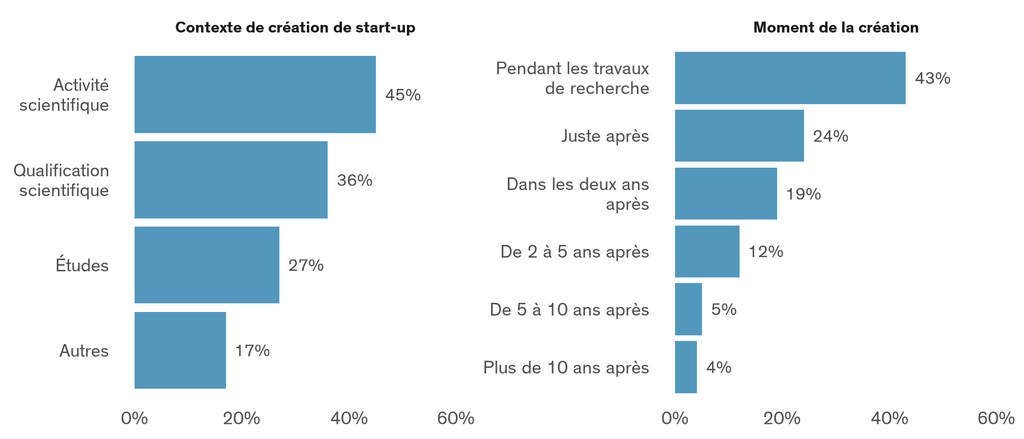

Données : contributions d’Innosuisse et du FNS à la création et au développement de start-up basées sur la science (Fraunhofer ISI, 2023). Réponses de 197 start-ups avec plusieurs réponses possibles.

Environnement de recherche

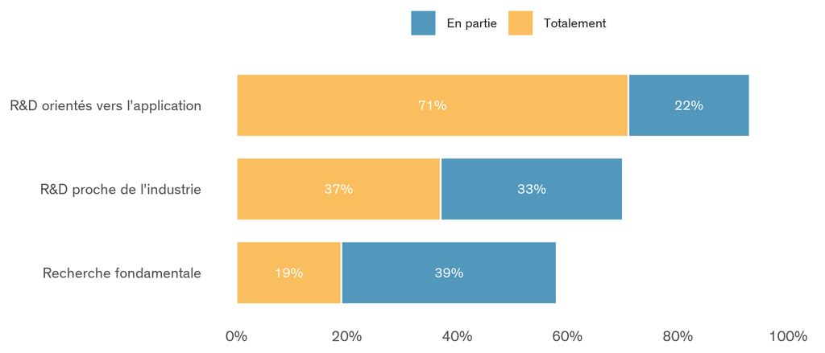

Données : contributions d’Innosuisse et du FNS à la création et au développement de start-up basées sur la science (Fraunhofer ISI, 2023). Réponses de 129 start-ups avec plusieurs réponses possibles.

### Plusieurs sources importantes de soutien

Une activité ou une qualification scientifiques sont à l’origine de 129 start-up ayant participé à l’enquête. L’étude a examiné si leur création était liée à des travaux de recherche subventionnés. 103 start-up (80%) ont déclaré avoir reçu un soutien à la recherche. Comme sources importantes de soutien, elles ont cité Innosuisse, les contributions d’encouragement propres aux hautes écoles, le FNS, d’autres bailleurs de fonds, les programmes de l’UE et le programme BRIDGE du FNS et d’Innosuisse.

Provenance des subventions

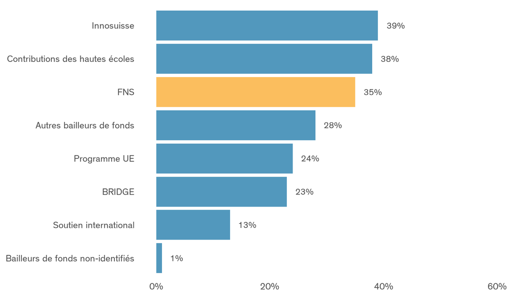

Données : contributions d’Innosuisse et du FNS à la création et au développement de start-up basées sur la science (Fraunhofer ISI, 2023). Réponses de 103 start-ups avec plusieurs réponses possibles.

Ces instruments du FNS ont contribué à la création de start-up

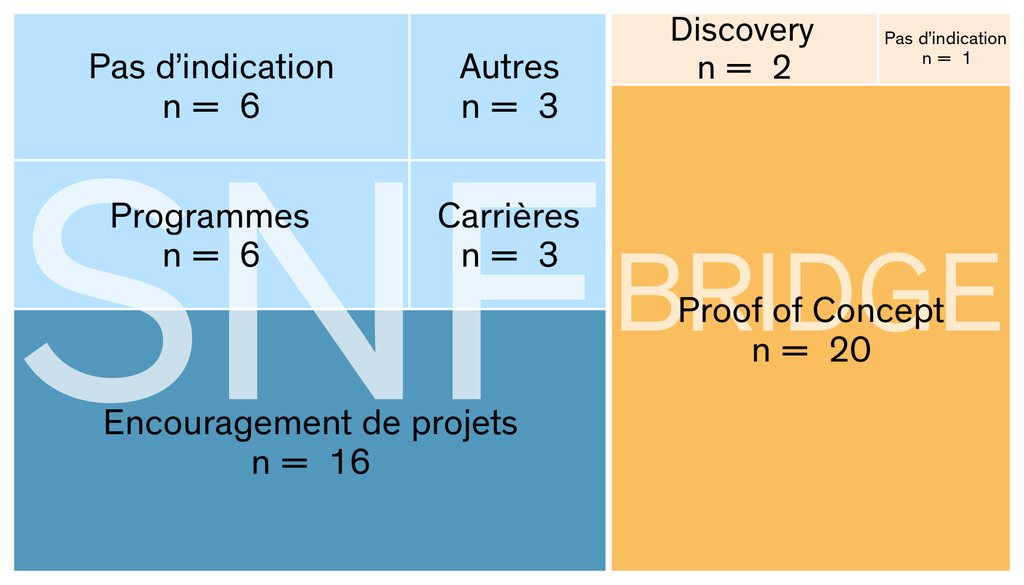

Données : contributions d’Innosuisse et du FNS à la création et au développement de start-up basées sur la science (Fraunhofer ISI, 2023).

L’étude a demandé aux start-up, dont les travaux de recherche ont été soutenus par le FNS et Innosuisse, à quel point ce soutien avait pu contribuer à leur création. Dans la plupart des cas, elles ont répondu que leurs résultats de recherche ont constitué la base technologique de la création de l’entreprise ou le cœur de son idée commerciale. Ce soutien a également permis aux scientifiques d’acquérir d’autres compétences professionnelles et de tisser des réseaux qui se sont avérés utiles par la suite, lorsqu’il s’est agi de créer l’entreprise. C’est au cours d’un projet que les scientifiques ont souvent eu envie d’exploiter les résultats de leurs propres recherches en créant une start-up. Et la planification de la création de leur start-up a aussi pu progresser durant le projet.

### Trois exemples de start-up : substances actives, géothermie et vidange de la vessie

Une spin-off technologique a développé à partir de 2015 des outils innovants pour la recherche pré-clinique de substances actives et la recherche biologique. L’entreprise dispose désormais de sa propre ligne de produits brevetés. L’idée de sa création est née dans le cadre de travaux de recherche de longue haleine soutenus par le FNS et s’est déroulée parallèlement aux travaux scientifiques de l’équipe fondatrice.

Une autre start-up créée en 2021 en tant que spin-off technologique produit des panneaux géothermiques, dont l’installation est simple, et qui permettent par exemple de faire bénéficier des appartements de la chaleur renouvelable captée dans des infrastructures souterraines, comme des parkings. Un financement du programme BRIDGE du FNS et d’Innosuisse a permis de finaliser les dernières étapes de son développement technologique. De plus, l’entreprise a également bénéficié du soutien d’Innosuisse sous la forme de formations et de coachings de démarrage.

L’idée commerciale de la troisième start-up se focalise sur le développement et la vente en ligne d’un dispositif médical non invasif d’aide à la vidange de la vessie. L’entreprise a également été créée en 2021 et toutes les personnes fondatrices ont un parcours universitaire. Un financement de BRIDGE a soutenu la démonstration de faisabilité du projet. Par la suite, Innosuisse a encouragé les travaux de recherche dans le cadre d’un projet d’innovation.

### Utiliser les potentiels au profit de la société et de l’économie

Pour le FNS, cette étude est source d’informations importantes. Il s’est ainsi avéré que les doctorats et l’activité scientifique (par exemple les post-doctorats) jouent un rôle important dans la création de start-up. Souvent, les fondateurs·rices développent l’idée commerciale au cours des travaux de recherche. Il est également important de noter que différents instruments du FNS sont propices à la création d’innovations et de start-up.

De manière générale, l’étude montre que la société et l’économie peuvent bénéficier rapidement et pleinement des résultats de la recherche. Ce n’est pas pour rien que l’une des priorités du FNS dans son programme pluriannuel pour la période 2025-2028 s’intitule « Exploiter l’intégralité du potentiel de la recherche ».

**Liens complémentaires**

[Étude (en allemand uniquement) (PDF)](https://www.snf.ch/media/de/FX8uh6uwOzEDIb6M/Schlussbericht_Start-up_Studie.pdf)

[Résumé de l’étude (PDF)](https://www.snf.ch/media/fr/cqHkBkWVvu3JbTIp/Kurzfassung_Start-up_FR.pdf)

[Innosuisse](https://www.innosuisse.ch/inno/fr/home.html)

Les données, le texte et le code de ce récit de données sont [disponibles sur Github](https://github.com/snsf-data/datastory_start_ups) et [archivés sur Zenodo](https://doi.org/10.46446/datastory.start-ups).  
DOI : 10.46446/datastory.start-ups